# practicum_2.3

### Checking outliers

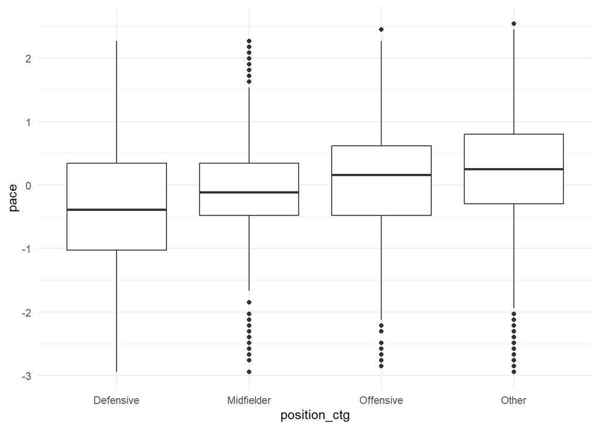

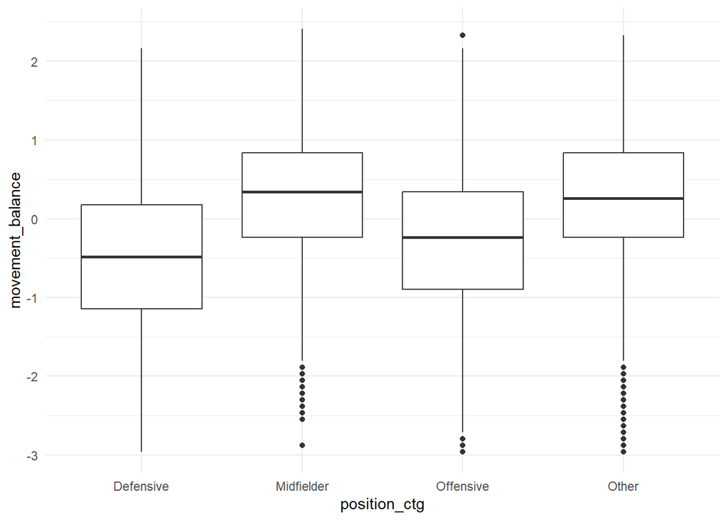

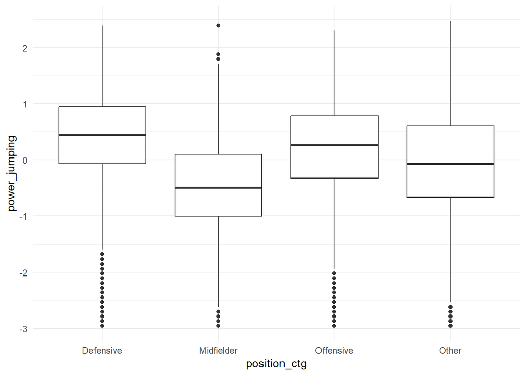

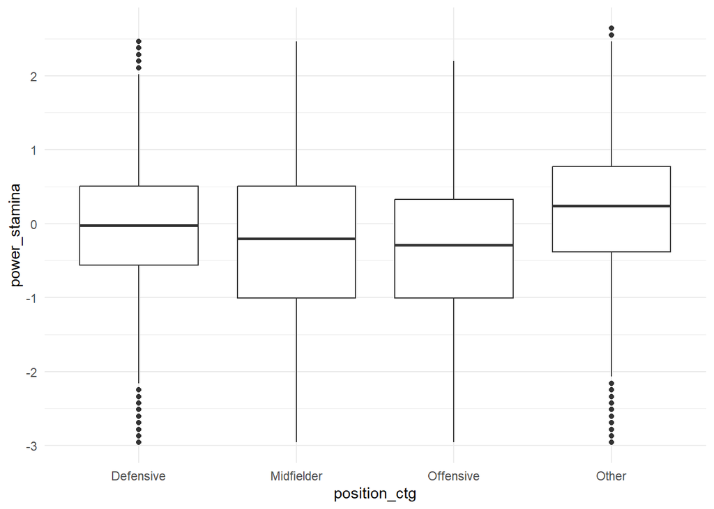

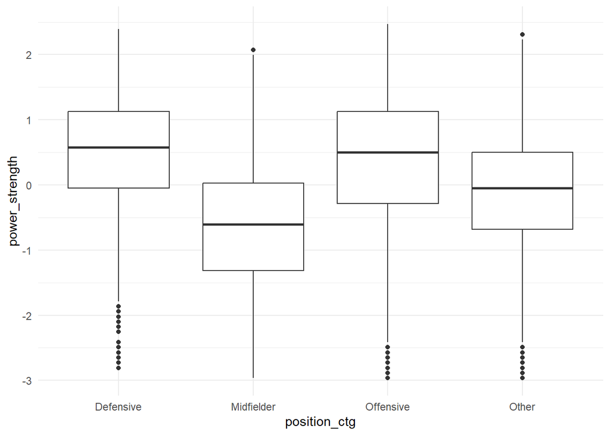

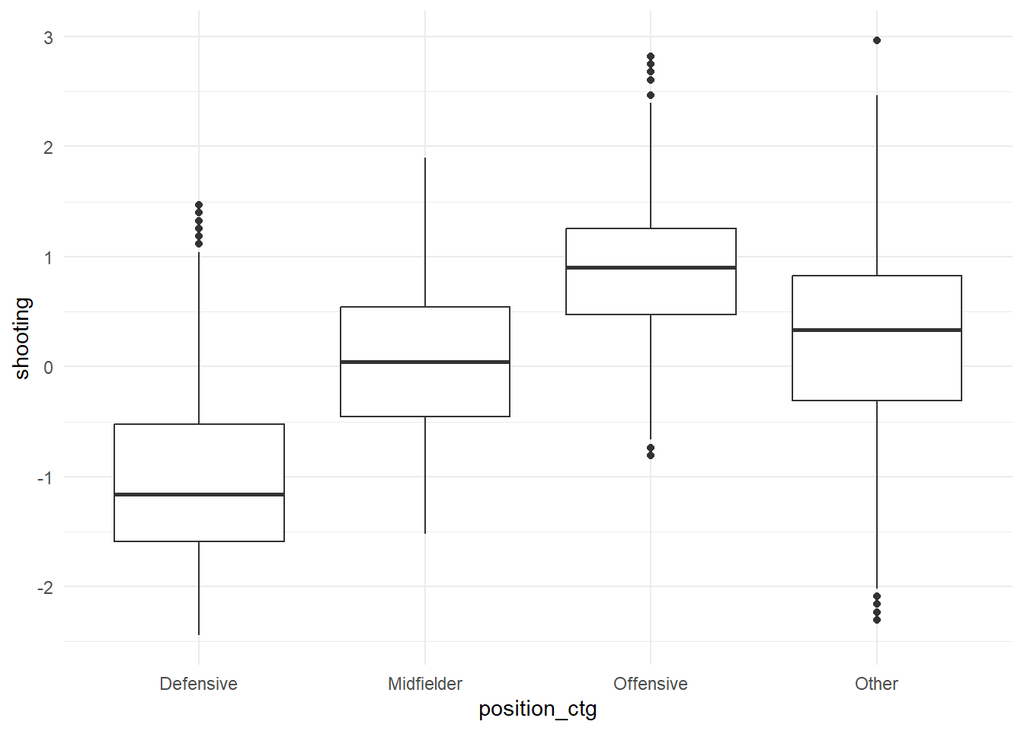

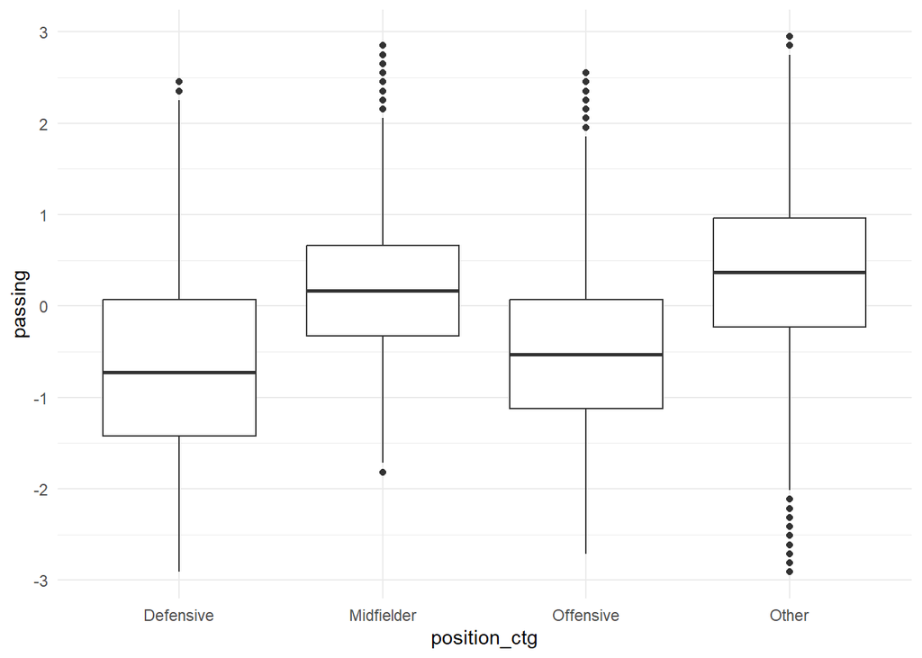

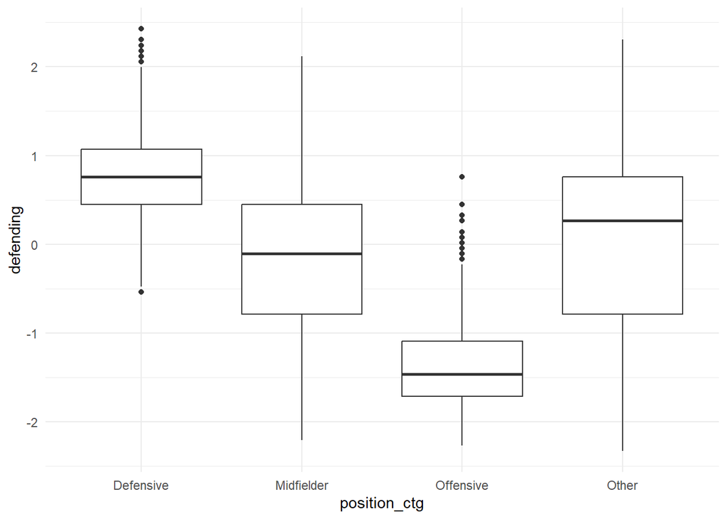

```r
show.boxplot <- function(data, cols, target){
  plots <- map(cols, ~ggplot(
    data,
    aes(x = .data[[target]], y = .data[[.x]])) +
      geom_boxplot(aes(group = .data[[target]])) +
      theme_minimal()
  )

  walk(plots, print)
}

show.boxplot(data = fifa_df, cols = predictors, target = target)
```

## Training, Tuning and Testing

### Logistic Regression

```r
# decay is a regularization parameter (L2 penalty) used in multinomial logistic regression (multinom from the nnet package). It prevents overfitting by penalizing large coefficient values.
# Regularization is a technique that adds a penalty to large weights (coefficients) to reduce model complexity and improve generalization.

# λ (decay) controls the penalty strength.
#A higher decay value increases the penalty, leading to smaller coefficients.
#A lower decay value allows larger coefficients and reduces regularization.

# Each coefficient represents the change in the log-odds of being in a given category (compared to the reference category) for a one-unit increase in that predictor. Positive values indicate growth in the probability (log odds), whereas
# negative values decrease the probability.
# Intercept - represents the baseline log-odds of a player belonging to that category (e.g., Midfielder) when all predictors are zero.

# Standard error - each coefficient has an associated standard error, which measures the variability of the estimated coefficient. Larger standard errors indicate more uncertainty in the coefficient estimates.Smaller standard errors indicate more confidence in the estimates.

# Residual Deviance - lower values indicate a better fit, how well the model
# predicts the data
# D=−2×∑log(L), where L is the likelihood of the model given the data.
# Compared to a null model (only intercept, no predictors):
#If Residual Deviance is much lower, the predictors improve classification.
#If it’s close to the null deviance, the predictors do not improve classification much.

# AIC - a lower values indicate a better model, it balances model fit and its
# complexity, lower values suggest best balance between accuracy and simplicity.
# Higher values - too complex or poor fit.
# AIC=D+2k

#Larger standard errors indicate more uncertainty in the coefficient estimates.
#Smaller standard errors indicate more confidence in the estimates.

formula <- as.formula(paste("position_ctg ~", paste(predictors, collapse = " + ")))
log_model <- train(formula,
                   data = fifa_df,
                   method = "multinom",
                   trControl = trainControl(method = "cv", number = 5),
                   tuneGrid = expand.grid(decay = c(0.001, 0.01, 0.1)),
                   metric = "Accuracy")  # Regularization parameter
# if the log-likelihood values are not changing significantly, the model
# has reached convergence
#

#In multinomial logistic regression, one class is chosen as the reference category (baseline), and all other classes are compared against it. In this case, "Defensive" is the reference category, meaning all coefficient values describe how different Midfielder, Offensive, and Other players are compared to Defensive players.
# Check model summary
summary(log_model)
```

```
## Call:
## nnet::multinom(formula = .outcome ~ ., data = dat, decay = param$decay)
##
## Coefficients:
##            (Intercept)       pace movement_balance power_jumping power_stamina
## Midfielder   0.6090943 -0.7148259       0.06118799  -0.335793737    0.09440159
## Offensive   -1.5387201 -0.6954685      -0.09055639  -0.002999351    0.05562629
## Other        2.6256867 -0.1558998       0.10036204  -0.155884164    0.07248751
##            power_strength  shooting    passing defending
## Midfielder    -0.53791997 0.3887602  1.3452411 -2.325688
## Offensive      0.14310976 3.4253533 -0.7969007 -3.210659
## Other         -0.03156556 0.5622617  1.1890327 -2.120205
##
## Std. Errors:
##            (Intercept)       pace movement_balance power_jumping power_stamina
## Midfielder  0.06634542 0.05003730       0.05562348    0.04474607    0.04866997
## Offensive   0.11702505 0.06405223       0.06938984    0.05649368    0.06436268
## Other       0.05897484 0.03613951       0.04105674    0.03479287    0.03735320
##            power_strength   shooting    passing  defending
## Midfielder     0.05825912 0.07678815 0.07820504 0.09059055
## Offensive      0.07328847 0.12481835 0.09738899 0.10918769
## Other          0.04654238 0.05370833 0.05841013 0.07887631
##
## Residual Deviance: 22419.04
## AIC: 22473.04
```

Features like *power_jumping* or *power_stamina* have coefficient values close to 0, meaning they have only little effect on classification and should be removed.

Defending have quite high negative coefficients meaning that **higher defending ability reduces the chance of being in any class other than Defensive**.

### SVM

```r
library(caret)
library(e1071)
# Define hyperparameter grid with both sigma and C
# C (Cost), controls trade-off between maximizing the margin
# and minimizing the classification errors
# lower C means higher margin, but permitting more missclassifcations
# higher C aims for perfect classification but there is risk of overfitting
# sigma - (RBF kernel width) controls the spread of radial basis function (RBF)
# A small sigma results in high variance (overfitting), while large sigma results
# in underfitting
# degree (polynomial kernel degree), used only for svmPoly, higher values create
# more complex decision boundaries
# scale - determines whether to normalize the data before training

# svm_grid_rbf <- expand.grid(sigma = c(0.01, 0.1),  # Sigma for RBF kernel
#                         C = c(0.1, 1))  # Cost parameter

svm_control <- trainControl(method = "cv",
                            number = 5,
                            classProbs = TRUE)  # Enable probability estimation

# Train SVM with polynomial kernel WITH probability estimates
svm_grid_poly <- expand.grid(degree = 2,  # Simpler polynomial
  scale = 0.01,  # Smaller scale
  C = 1)  # Moderate regularization)


svm_model_poly <- train(
  formula,
  data = fifa_df,
  method = "svmPoly",
  trControl = svm_control,  # Use the updated trainControl
  tuneGrid = svm_grid_poly,
  metric = "Accuracy",
  probability = TRUE
)
```

[output not shown]

```r
# svm_model_poly <- train(
#   formula,
#   data = fifa_df,
#   method = "svmPoly",
#   trControl = trainControl(method = "cv",
#                           number = 5),  # Enable class probabilities
#   tuneGrid = svm_grid_poly,
#   metric = "Accuracy",
#   probability = TRUE  # Critical for SVM probability estimates
# )

print(svm_model_poly)
```

```
## Support Vector Machines with Polynomial Kernel
##
## 16590 samples
##     8 predictor
##     4 classes: 'Defensive', 'Midfielder', 'Offensive', 'Other'
##
## No pre-processing
## Resampling: Cross-Validated (5 fold)
## Summary of sample sizes: 13271, 13272, 13273, 13272, 13272
## Resampling results:
##
##   Accuracy   Kappa
##   0.4904159  0.3341514
##
## Tuning parameter 'degree' was held constant at a value of 2
## Tuning
##  parameter 'scale' was held constant at a value of 0.01
## Tuning parameter
##  'C' was held constant at a value of 1
```

**Accuracy** means proportion of correctly classified samples. Higher is better. **Kappa** measures agreement between the predicted and actual classifications, accounting for chance. Higher is better.

### LDA / QDA

```r
library(caret)
set.seed(123)  # For reproducibility

# Define train control for cross-validation
train_control <- trainControl(method = "cv", number = 5)

# Train LDA model using caret
lda_model <- train(
  formula,
  data = fifa_df,
  method = "lda",
  trControl = train_control
)

# Print results
print(lda_model)
```

```
## Linear Discriminant Analysis
##
## 16590 samples
##     8 predictor
##     4 classes: 'Defensive', 'Midfielder', 'Offensive', 'Other'
##
## No pre-processing
## Resampling: Cross-Validated (5 fold)
## Summary of sample sizes: 13272, 13271, 13272, 13272, 13273
## Resampling results:
##
##   Accuracy   Kappa
##   0.7089814  0.4794942
```

```r
set.seed(123)

qda_model <- train(
  formula,
  data = fifa_df,
  method = "qda",
  trControl = train_control
)

print(qda_model)
```

```
## Quadratic Discriminant Analysis
##
## 16590 samples
##     8 predictor
##     4 classes: 'Defensive', 'Midfielder', 'Offensive', 'Other'
##
## No pre-processing
## Resampling: Cross-Validated (5 fold)
## Summary of sample sizes: 13272, 13271, 13272, 13272, 13273
## Resampling results:
##
##   Accuracy   Kappa
##   0.6936711  0.4799585
```

```r
# fifa_df$position_ctg <- as.factor(fifa_df$position_ctg)
# str(fifa_df$position_ctg)  # Should show 'Factor' with levels
# levels(fifa_df$position_ctg)  # Should return e.g., "Offensive", "Defensive", etc.
```

### ROC Curves

```
## [1] "AUC for Defensive : 0.922054560566563"
```

```
## [1] "AUC for Midfielder : 0.795025553187756"
```

```
## [1] "AUC for Offensive : 0.96803722351414"
```

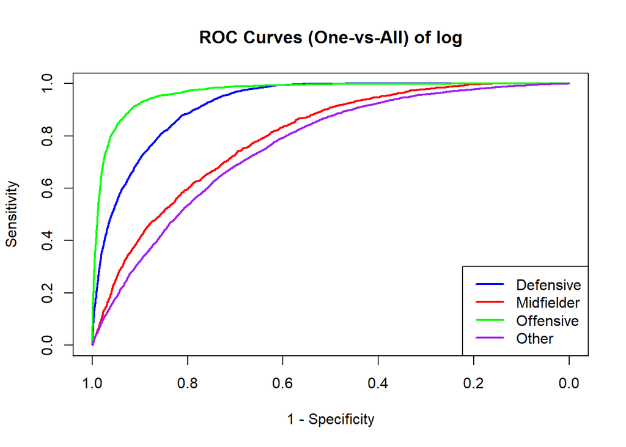

```
## [1] "AUC for Other : 0.760336193422762"
```

```
## [1] "AUC for Defensive : 0.927442557139769"
```

```
## [1] "AUC for Midfielder : 0.801436532680363"
```

```
## [1] "AUC for Offensive : 0.95269171663637"
```

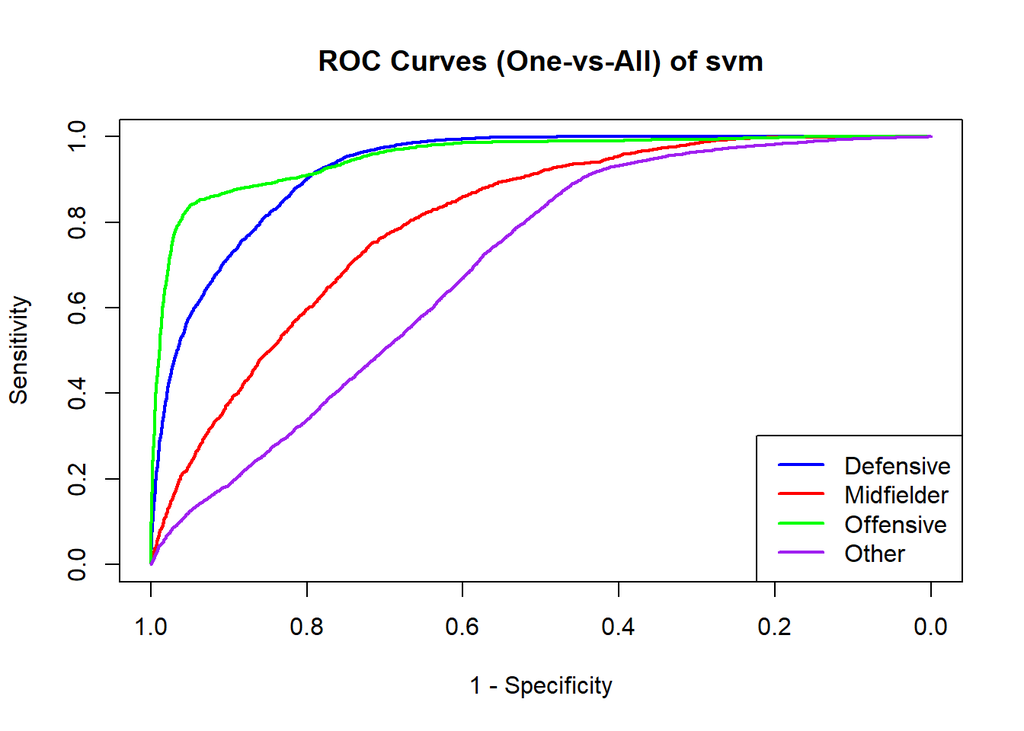

```
## [1] "AUC for Other : 0.694822221409799"
```

```
## [1] "AUC for Defensive : 0.927442557139769"
```

```
## [1] "AUC for Midfielder : 0.801436532680363"
```

```
## [1] "AUC for Offensive : 0.95269171663637"
```

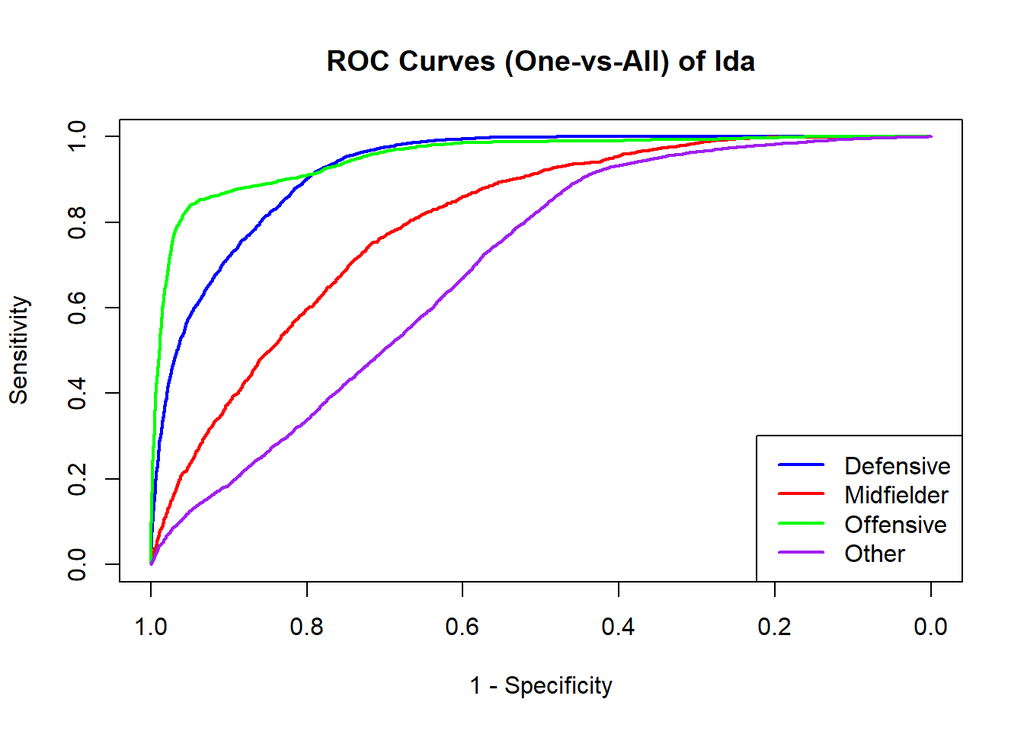

```
## [1] "AUC for Other : 0.694822221409799"
```

```
## [1] "AUC for Defensive : 0.918847837909565"
```

```
## [1] "AUC for Midfielder : 0.826600912222397"
```

```
## [1] "AUC for Offensive : 0.96862843856959"
```

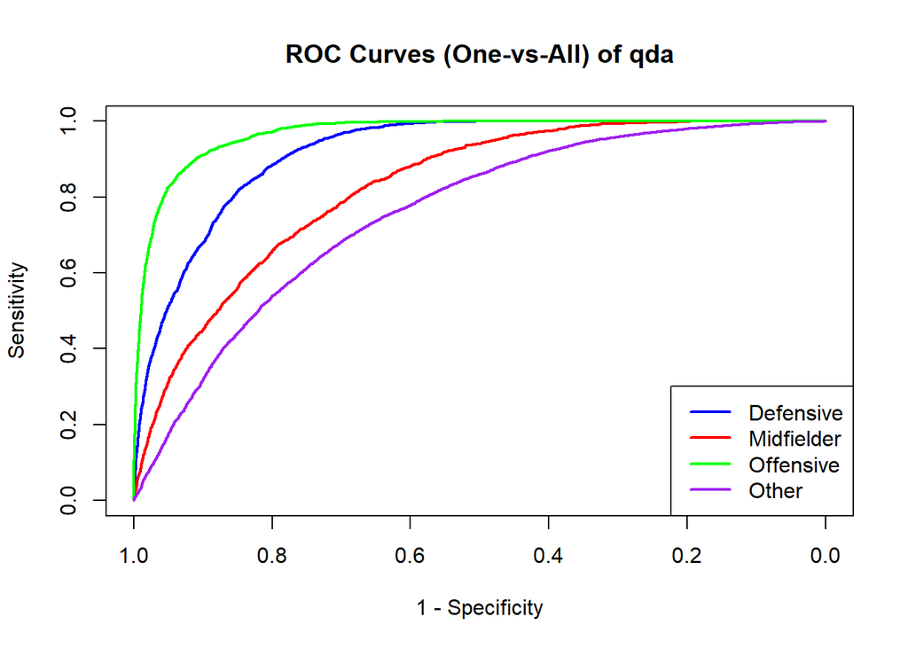

```
## [1] "AUC for Other : 0.756512142506742"
```

[output not shown]

[output cut: 38 more lines]

[output not shown]

```r
# ROC Curve
# y axis - sensitivity (true positives)
# x axis - specificity (false positives)

# library(caret)
library(pROC)
library(ROCR)
set.seed(123)

show.ROC <- function(model_probs, model_name){
  # Loop through each class and plot ROC
  classes <- levels(fifa_df$position_ctg)
  colors <- c("blue", "red", "green", "purple")  # Adjust based on number of classes

  par(mfrow = c(1, 1))  # Reset plot layout
  plot(NA, xlim = c(1, 0), ylim = c(0, 1), xlab = "1 - Specificity", ylab = "Sensitivity", main = paste0("ROC Curves (One-vs-All) of ", model_name))
  for (i in seq_along(classes)) {
    roc_curve <- roc(
      response = fifa_df$position_ctg == classes[i],
      predictor = model_probs[[classes[i]]]
    )
    lines(roc_curve, col = colors[i], lwd = 2)
    print(paste("AUC for", classes[i], ":", auc(roc_curve)))
  }
  legend("bottomright", legend = classes, col = colors, lwd = 2)
}

# Train LDA model
# train_control <- trainControl(method = "cv", number = 5, classProbs = TRUE)
# lda_model <- train(formula, data = fifa_df, method = "lda", trControl = train_control)

# Get predicted probabilities (one column per class)
log_probs <- predict(log_model, fifa_df, type = "prob")
svm_probs <- predict(svm_model_poly, fifa_df, type = "prob")
lda_probs <- predict(svm_model_poly, fifa_df, type = "prob")
qda_probs <- predict(qda_model, fifa_df, type = "prob")


probs <- list(log = log_probs, svm = svm_probs, lda = lda_probs, qda = qda_probs)

# Apply the function to each model
imap(probs, show.ROC)
```

### Optimal probability cut-off

```r
#Suppose the optimal cut-off for "Offensive" is 0.65.
#A player with P(Offensive) = 0.70 is classified as Offensive.
#A player with P(Offensive) = 0.50 is classified as Not Offensive.

for (class in classes){
  # For binary classification (one class vs. rest)
  roc_curve <- roc(
    response = fifa_df$position_ctg == class,  # Example for "Offensive" class
    predictor = lda_probs[[class]]            # Predicted probabilities for "Offensive"
  )

  # Get optimal cut-off (Youden’s Index)
  optimal_cutoff <- coords(roc_curve, "best", ret = "threshold", best.method = "youden")
  print(paste("Optimal Cut-off:", optimal_cutoff))
}
```

```
## [1] "Optimal Cut-off: 0.280514292532991"
```

```
## [1] "Optimal Cut-off: 0.343162568315361"
```

```
## [1] "Optimal Cut-off: 0.266630834793312"
```

```
## [1] "Optimal Cut-off: 0.26969450009321"
```

### Thresholds

```
##
## === Interpretation of  log  for class: Defensive ===
```

```
## Optimal probability cutoff for Defensive : 0.197
## Predictor: pace
## - 19.7% of Defensive players have pace ≤ -1.2
## - 80.3% of Defensive players have pace > 0.4
##
## Predictor: movement_balance
## - 19.7% of Defensive players have movement_balance ≤ -1.3
## - 80.3% of Defensive players have movement_balance > 0.3
##
## Predictor: power_jumping
## - 19.7% of Defensive players have power_jumping ≤ -0.2
## - 80.3% of Defensive players have power_jumping > 1.2
##
## Predictor: power_stamina
## - 19.7% of Defensive players have power_stamina ≤ -0.7
## - 80.3% of Defensive players have power_stamina > 0.7
##
## Predictor: power_strength
## - 19.7% of Defensive players have power_strength ≤ -0.3
## - 80.3% of Defensive players have power_strength > 1.2
##
## Predictor: shooting
## - 19.7% of Defensive players have shooting ≤ -1.7
## - 80.3% of Defensive players have shooting > -0.4
##
## Predictor: passing
## - 19.7% of Defensive players have passing ≤ -1.5
## - 80.3% of Defensive players have passing > 0.2
##
## Predictor: defending
## - 19.7% of Defensive players have defending ≤ 0.4
## - 80.3% of Defensive players have defending > 1.2
##
##
## === Interpretation of  log  for class: Midfielder ===
```

```
## Optimal probability cutoff for Midfielder : 0.088
## Predictor: pace
## - 8.8% of Midfielder players have pace ≤ -1
## - 91.2% of Midfielder players have pace > 1
##
## Predictor: movement_balance
## - 8.8% of Midfielder players have movement_balance ≤ -0.7
## - 91.2% of Midfielder players have movement_balance > 1.3
##
## Predictor: power_jumping
## - 8.8% of Midfielder players have power_jumping ≤ -1.7
## - 91.2% of Midfielder players have power_jumping > 0.8
##
## Predictor: power_stamina
## - 8.8% of Midfielder players have power_stamina ≤ -1.8
## - 91.2% of Midfielder players have power_stamina > 1.3
##
## Predictor: power_strength
## - 8.8% of Midfielder players have power_strength ≤ -2
## - 91.2% of Midfielder players have power_strength > 0.6
##
## Predictor: shooting
## - 8.8% of Midfielder players have shooting ≤ -0.9
## - 91.2% of Midfielder players have shooting > 1
##
## Predictor: passing
## - 8.8% of Midfielder players have passing ≤ -0.8
## - 91.2% of Midfielder players have passing > 1.3
##
## Predictor: defending
## - 8.8% of Midfielder players have defending ≤ -1.4
## - 91.2% of Midfielder players have defending > 0.9
##
##
## === Interpretation of  log  for class: Offensive ===
```

```
## Optimal probability cutoff for Offensive : 0.099
## Predictor: pace
## - 9.9% of Offensive players have pace ≤ -1.2
## - 90.1% of Offensive players have pace > 1.2
##
## Predictor: movement_balance
## - 9.9% of Offensive players have movement_balance ≤ -1.6
## - 90.1% of Offensive players have movement_balance > 0.9
##
## Predictor: power_jumping
## - 9.9% of Offensive players have power_jumping ≤ -1.1
## - 90.1% of Offensive players have power_jumping > 1.4
##
## Predictor: power_stamina
## - 9.9% of Offensive players have power_stamina ≤ -1.4
## - 90.1% of Offensive players have power_stamina > 0.8
##
## Predictor: power_strength
## - 9.9% of Offensive players have power_strength ≤ -1.2
## - 90.1% of Offensive players have power_strength > 1.5
##
## Predictor: shooting
## - 9.9% of Offensive players have shooting ≤ 0.1
## - 90.1% of Offensive players have shooting > 1.6
##
## Predictor: passing
## - 9.9% of Offensive players have passing ≤ -1.6
## - 90.1% of Offensive players have passing > 0.7
##
## Predictor: defending
## - 9.9% of Offensive players have defending ≤ -2
## - 90.1% of Offensive players have defending > -0.7
##
##
## === Interpretation of  log  for class: Other ===
```

```
## Optimal probability cutoff for Other : 0.575
## Predictor: pace
## - 57.5% of Other players have pace ≤ 0.4
## - 42.5% of Other players have pace > 0.1
##
## Predictor: movement_balance
## - 57.5% of Other players have movement_balance ≤ 0.4
## - 42.5% of Other players have movement_balance > 0.2
##
## Predictor: power_jumping
## - 57.5% of Other players have power_jumping ≤ 0.2
## - 42.5% of Other players have power_jumping > -0.2
##
## Predictor: power_stamina
## - 57.5% of Other players have power_stamina ≤ 0.4
## - 42.5% of Other players have power_stamina > 0.1
##
## Predictor: power_strength
## - 57.5% of Other players have power_strength ≤ 0.1
## - 42.5% of Other players have power_strength > -0.2
##
## Predictor: shooting
## - 57.5% of Other players have shooting ≤ 0.5
## - 42.5% of Other players have shooting > 0.2
##
## Predictor: passing
## - 57.5% of Other players have passing ≤ 0.5
## - 42.5% of Other players have passing > 0.2
##
## Predictor: defending
## - 57.5% of Other players have defending ≤ 0.5
## - 42.5% of Other players have defending > 0
##
## \newpage
```

[output not shown]

[output cut: 559 more lines]

[output not shown]

### Type I and II errors

We select lowest misclassification rate because:

- When **all errors are equally costly** (e.g., spam detection, image classification).
- When the class distribution is **balanced** (similar proportions of classes).
- Optimizes for the **highest overall correctness**.
- Simple and interpretable, but **risky for imbalanced data** (e.g., a model could achieve 95% accuracy by always predicting the majority class).

Type I error - when false alarms are critical (e.g. medical diagnosis, fraud detection).

Type II error - when **missing a positive case is costly** (e.g., cancer screening, security threats).